# IADS midterm

Noran Abdou na3122@nyu.edu

Please ensure all code is executed and the corresponding outputs are included. Write the code directly in this notebook rather than creating a new one.

## Part 1: Multiple choice and theoretic questions

Please write your answer after each question

### Question 1. What would the p-value of 0.04 mean for t-test comparing two samples of observations (select all that applies):

A) sample averages are at least 4% different

B) the samples follow the underlying distributions with the same mean

C) the samples follow the underlying distributions with the different mean

D) one can reject the null hypothesis that the samples follow the underlying distributions with the same mean at 5% significance level (or with 95% confidence) since p-values is below 0.05

E) one can't reject the null hypothesis that the samples follow the underlying distributions with the same mean at 5% significance level (or 95% confidence) singe p-value does not reach 0.05

F) one can reject the null hypothesis that the samples follows the underlying distributions with the different means at 5% significance level (or 95% confidence)

G) probability that two samples have the same means is 4%

Answer: D is correct

### Question 2. What is true regarding normal and log-normal distributions:

A) Quantities following log-normal distributions have higher probabilities for outliers compared to normal distributions

B) Outliers significantly different from the mean are more common for the normally distributed variables compared to log normally distributed variables

C) Logarithm of the normally distributed quantity follow a log-normal distribution

D) Logarithm of the log-normally distributed quantity follows a normal distribution

E) Probability density function of the log-normally distributed variable equals to the logarithm of the probability density function of the normally distributed variable

Answer: A and D are correct

### Question 3.

Imagine training a model which considers multiple sattelite images of urban traffic and tries to find groups of typical (repeated with minor deviations) scenarios. How would you classify this problem from Machine Learning perspective?

A) Supervised leanring;

B) Unsupervised learning;

C) Semi-supervised learning;

D) Reinforcement learning.

Explain you choice:

Answer: B is correct. This is an unsupervised learning problem. We are trying to find groups of typical traffic scenarios without labeled data. The task is exploratory in nature in order to discover patterns in data

### Question 4.

Please explain why would you need separate training, validation and test samples to learn the model. In which cases you may need all three, including a validation sample?

Answer:

Training sample: This is used to fit the model and adjust the model parameters.

Validation sample: This is used to fine-tune the model, such as choosing hyperparameters, and to avoid overfitting the model to the training data. Validation is particularly important when the model requires optimization over multiple configurations.

Test sample: This is used to evaluate the model's performance after training and validation to get an unbiased estimate of the model's generalization to new data.

We need all three samples when tuning model parameters (especially in complex models like neural networks or in machine learning pipelines), so that the final test evaluation is not influenced by model adjustments made during validation.

```python
!pip install numpy
!pip install rtree
!pip install pygeos
!pip install geopandas
!pip install panda
!pip install seaborn
```

```python
import pandas as pd
import numpy as np
from datetime import datetime
from dateutil import parser
import seaborn as sns
from scipy.stats import norm
from scipy.stats import genextreme as gev
from scipy.stats import pareto
from scipy import stats
import geopandas as gpd
from shapely.geometry import Point
from matplotlib import pyplot as plt
%matplotlib inline
import warnings
warnings.filterwarnings('ignore')
```

## Part 2: NYPD data analysis

In this part, you need to download New York Police Department (NYPD) complaints data for 2019 and write code for three following sections (each having own sub-sections): Data cleaning, Exploratory analysis and Hypothesis testing

### download NYPD complaints data:

two options:

1. download with curl or urllib methods
2. download with API

```python
import urllib.request

url = "https://data.cityofnewyork.us/api/views/qgea-i56i/rows.csv?accessType=DOWNLOAD"

file_name = "C:/Users/AbdouN/OneDrive - AECOM/Documents/Midterm/NYPD_data.csv"

urllib.request.urlretrieve(url, file_name)

print(f"Download complete! File saved to: {file_name}")
```

Data dictionary: https://data.cityofnewyork.us/api/views/qgea-i56i/files/b21ec89f-4d7b-494e-b2e9-f69ae7f4c228?download=true&filename=NYPD_Complaint_Incident_Level_Data_Footnotes.pdf

### read data

```python
data = pd.read_csv('NYPD_data.csv')
data.head()
```

```python
data.shape
```

#### the shape of the data frame should be (8914838, 35)

```python
data.OFNS_DESC.unique()
```

```python
data.columns
```

The complete data dictionary link is provided above. The focus of this notebook would be on columns - 'CMPLNT_NUM', 'CMPLNT_FR_DT', 'CMPLNT_FR_TM', 'OFNS_DESC', 'BORO_NM', 'PARKS_NM', 'Latitude', 'Longitude'.

The 'CMPLNT_NUM' is a unique id for each complaint, 'CMPLNT_FR_DT' and 'CMPLNT_FR_TM' are date and time of complaint respectively, 'OFNS_DESC' is the type of offence reported, 'BORO_NM' is name of borough where complaint was reported, 'PARKS_NM' is name of park where complaint recorded (if any) and 'Latitude', 'Longitude' are location of complaint.

## Section 1 - Data cleaning tasks

#### We have completed the majority of the data cleaning tasks, but there are still a few remaining items for you to address.(Marked as 'todo')

1. Drop rows with a) missing/wrong complaint date and time b) missing borough name and c) duplicate complaint number ('CMPLNT_NUM' column)
2. Filter out data where incident occured in a park or greenspace. Next, keep data for 2019 and after.
3. Keep specific crime categories - type 1 crimes defined by FBI: The list is given here https://ucr.fbi.gov/crime-in-the-u.s/2011/crime-in-the-u.s.-2011/offense-definitions
4. Filter by area (drop rows with location outside NYC)

### 1. filter out missing/wrong date and times, missing borough name and duplicate complaints from the data

```python
data.isna().sum()
```

```python
data['CMPLNT_FR_DT'] = pd.to_datetime(data['CMPLNT_FR_DT'], errors='coerce')
```

```python
data['CMPLNT_FR_TM'] = pd.to_datetime(data['CMPLNT_FR_TM'], format='%H:%M:%S', errors='coerce')
data['hour'] = data['CMPLNT_FR_TM'].dt.hour  # Extract hour from the datetime object
```

```python
print(data.CMPLNT_FR_DT.isna().sum())
print(data.CMPLNT_FR_TM.isna().sum())
```

```python
data.dropna(subset=['CMPLNT_FR_DT', 'CMPLNT_FR_TM'], inplace=True)
data.shape
```

```python
data.drop_duplicates(subset=['CMPLNT_NUM'], inplace=True)
data.shape
```

```python
data.BORO_NM.unique()
```

```python
data = data[~data.BORO_NM.isna()]
data = data[data.BORO_NM != '(null)']
data.shape
```

```python
data.BORO_NM.unique()
```

### 2. Remove rows where location is parks or greenspace and filter for 2019 and after

```python
## check the timeline of data
print(data.sort_values(by='CMPLNT_FR_DT', ascending=True).head(3)['CMPLNT_FR_DT'])
print(data.sort_values(by='CMPLNT_FR_DT', ascending=False).head(3)['CMPLNT_FR_DT'])
```

```python
# Ensure CMPLNT_FR_DT is in datetime format to handle date filtering
data['CMPLNT_FR_DT'] = pd.to_datetime(data['CMPLNT_FR_DT'], errors='coerce')

# Drop rows with NaT in the date column after conversion
data = data.dropna(subset=['CMPLNT_FR_DT'])
print(data.shape)
```

```python
# Todo: filter out the data before 2019-1-1
```

```python
# Filter data to include only records from 2019
data = data[data['CMPLNT_FR_DT'] >= '2019-01-01']
```

```python
print(data.sort_values(by='CMPLNT_FR_DT', ascending=True).head(1)['CMPLNT_FR_DT'].values[0])
print(data.sort_values(by='CMPLNT_FR_DT', ascending=False).head(1)['CMPLNT_FR_DT'].values[0])
```

```
2019-01-01T00:00:00.000000000
2023-12-31T00:00:00.000000000
```

```python
data.shape
```

```
(2392988, 38)
```

```python
data.PARKS_NM.unique()
```

```
array(['(null)', 'HUDSON RIVER PARK', 'CPL. THOMPSON PARK', ...,
       'UNNAMED PARK ON CLEARVIEW EXPRESSWAY',
       'BEACH 30TH STREET PLAYGROUND', 'GARDEN AT BEACH 36TH STREET'],
      dtype=object)
```

```python
gdf_nyc_crimes = data[data.PARKS_NM == '(null)']
gdf_nyc_crimes.shape
```

```
(2376447, 38)
```

#### Checkpoint: We should have around 2.38M records after this step

### 3. keep type 1 crimes as defined by FBI from the data :

https://ucr.fbi.gov/crime-in-the-u.s/2011/crime-in-the-u.s.-2011/offense-definitions

The crime type is present in the 'OFNS_DESC' column. You just need to keep the following categories: "'ARSON', 'BURGLARY', 'FELONY ASSAULT', 'GRAND LARCENY' ,'GRAND LARCENY OF MOTOR VEHICLE', 'MURDER & NON-NEGL. MANSLAUGHTER', 'RAPE', 'ROBBERY'"

```python
data.OFNS_DESC.unique()
```

```
array(['SEX CRIMES', 'HARRASSMENT 2', 'PETIT LARCENY', 'ARSON', 'ROBBERY',
       'RAPE', 'MISCELLANEOUS PENAL LAW', 'ASSAULT 3 & RELATED OFFENSES',
       'BURGLARY', 'MURDER & NON-NEGL. MANSLAUGHTER', 'DANGEROUS WEAPONS',
       'FELONY ASSAULT', 'POSSESSION OF STOLEN PROPERTY',
       'CRIMINAL MISCHIEF & RELATED OF', 'CRIMINAL TRESPASS',
       'VEHICLE AND TRAFFIC LAWS', 'GRAND LARCENY',
       'OFF. AGNST PUB ORD SENSBLTY &', 'ADMINISTRATIVE CODE',
       'THEFT-FRAUD', 'DANGEROUS DRUGS', 'OFFENSES AGAINST PUBLIC ADMINI',
       'INTOXICATED & IMPAIRED DRIVING', 'OFFENSES AGAINST THE PERSON',
       'GRAND LARCENY OF MOTOR VEHICLE', 'NYS LAWS-UNCLASSIFIED FELONY',
       'FRAUDS', 'OTHER STATE LAWS (NON PENAL LA',
       'UNAUTHORIZED USE OF A VEHICLE', 'OTHER OFFENSES RELATED TO THEF',
       'FORGERY', 'DISRUPTION OF A RELIGIOUS SERV',
       'AGRICULTURE & MRKTS LAW-UNCLASSIFIED', 'ENDAN WELFARE INCOMP',
       'KIDNAPPING', 'LOITERING/GAMBLING (CARDS, DIC',
       'OFFENSES INVOLVING FRAUD', 'KIDNAPPING & RELATED OFFENSES',
       "BURGLAR'S TOOLS", 'GAMBLING', 'HOMICIDE-NEGLIGENT,UNCLASSIFIE',
       'PETIT LARCENY OF MOTOR VEHICLE',
       'KIDNAPPING AND RELATED OFFENSES',
       'OFFENSES AGAINST PUBLIC SAFETY', 'DISORDERLY CONDUCT',
       'ALCOHOLIC BEVERAGE CONTROL LAW', 'FELONY SEX CRIMES',
       'HOMICIDE-NEGLIGENT-VEHICLE', 'NYS LAWS-UNCLASSIFIED VIOLATION',
       'THEFT OF SERVICES', 'FRAUDULENT ACCOSTING', 'ESCAPE 3',
       'PROSTITUTION & RELATED OFFENSES', 'CHILD ABANDONMENT/NON SUPPORT',
       'JOSTLING', 'OTHER STATE LAWS', 'UNLAWFUL POSS. WEAP. ON SCHOOL',
       '(null)', 'OFFENSES RELATED TO CHILDREN', 'ANTICIPATORY OFFENSES',
       'OTHER STATE LAWS (NON PENAL LAW)', 'INTOXICATED/IMPAIRED DRIVING',
       'OTHER TRAFFIC INFRACTION', 'OFFENSES AGAINST MARRIAGE UNCL',
       'FORTUNE TELLING', 'NEW YORK CITY HEALTH CODE',
       'CANNABIS RELATED OFFENSES', 'LOITERING'], dtype=object)
```

```python
data_type1 = data[data.OFNS_DESC.isin(['ARSON', 'BURGLARY', 'FELONY ASSAULT', 'GRAND LARCENY' ,'GRAND LARCENY OF MOTOR VEHICLE',
                'MURDER & NON-NEGL. MANSLAUGHTER', 'RAPE', 'ROBBERY'])]
data_type1.reset_index(drop=True, inplace=True)
data_type1.shape
```

```
(548434, 38)
```

```python
data_type1.head()
```

|  | CMPLNT_NUM | CMPLNT_FR_DT | CMPLNT_FR_TM | CMPLNT_TO_DT | CMPLNT_TO_TM | ADDR_PCT_CD | RPT_DT | KY_CD | OFNS_DESC | PD_CD | ... | Longitude | Lat_Lon | PATROL_BORO | STATION_NAME | VIC_AGE_GROUP | VIC_RACE | VIC_SEX | hour | month | day_of_week |
| --- | --- | --- | --- | --- | --- | --- | --- | --- | --- | --- | --- | --- | --- | --- | --- | --- | --- | --- | --- | --- | --- |
| 0 | 238829557 | 2022-01-06 | 1900-01-01 23:09:00 | NaN | (null) | 6.0 | 01/08/2022 | 114 | ARSON | 263.0 | ... | -73.990849 | (40.734408, -73.990849) | PATROL BORO MAN SOUTH | (null) | UNKNOWN | UNKNOWN | E | 23 | January | Thursday |
| 1 | 239387040 | 2022-01-19 | 1900-01-01 15:50:00 | NaN | (null) | 44.0 | 01/19/2022 | 105 | ROBBERY | 366.0 | ... | -73.914543 | (40.832505, -73.914543) | PATROL BORO BRONX | (null) | 45-64 | BLACK | M | 15 | January | Wednesday |
| 2 | 238552254 | 2021-12-31 | 1900-01-01 00:01:00 | NaN | (null) | 17.0 | 01/02/2022 | 104 | RAPE | 157.0 | ... | -73.971143 | (40.7568201683051, -73.9711432633524) | PATROL BORO MAN SOUTH | (null) | 25-44 | WHITE | F | 0 | December | Friday |
| 3 | 245253070 | 2022-05-18 | 1900-01-01 12:05:00 | NaN | (null) | 43.0 | 05/18/2022 | 105 | ROBBERY | 380.0 | ... | -73.865076 | (40.83534287, -73.86507554) | PATROL BORO BRONX | (null) | 25-44 | UNKNOWN | M | 12 | May | Wednesday |
| 4 | 245512210 | 2022-05-08 | 1900-01-01 21:30:00 | NaN | (null) | 107.0 | 05/23/2022 | 104 | RAPE | 159.0 | ... | -73.810909 | (40.7301130668694, -73.8109089148815) | PATROL BORO QUEENS SOUTH | (null) | 25-44 | BLACK | F | 21 | May | Sunday |

5 rows × 38 columns

### 4. keep rows with location within NYC

zip codes file is present in the github 'Data' repository as "ZIPCODE.zip". We also have already used it in homework 2.

Do a spatial joint to keep only rows within NYC

```python
## zip codes map
zips = gpd.read_file(r'C:\Users\AbdouN\Midterm\ZIPCODE.zip')
zips.head()
```

|  | ZIPCODE | BLDGZIP | PO_NAME | POPULATION | AREA | STATE | COUNTY | ST_FIPS | CTY_FIPS | URL | SHAPE_AREA | SHAPE_LEN | geometry |
| --- | --- | --- | --- | --- | --- | --- | --- | --- | --- | --- | --- | --- | --- |
| 0 | 11436 | 0 | Jamaica | 18681.0 | 2.269930e+07 | NY | Queens | 36 | 081 | http://www.usps.com/ | 0.0 | 0.0 | POLYGON ((1038098.252 188138.38, 1038141.936 1... |
| 1 | 11213 | 0 | Brooklyn | 62426.0 | 2.963100e+07 | NY | Kings | 36 | 047 | http://www.usps.com/ | 0.0 | 0.0 | POLYGON ((1001613.713 186926.44, 1002314.243 1... |
| 2 | 11212 | 0 | Brooklyn | 83866.0 | 4.197210e+07 | NY | Kings | 36 | 047 | http://www.usps.com/ | 0.0 | 0.0 | POLYGON ((1011174.276 183696.338, 1011373.584 ... |
| 3 | 11225 | 0 | Brooklyn | 56527.0 | 2.369863e+07 | NY | Kings | 36 | 047 | http://www.usps.com/ | 0.0 | 0.0 | POLYGON ((995908.365 183617.613, 996522.848 18... |
| 4 | 11218 | 0 | Brooklyn | 72280.0 | 3.686880e+07 | NY | Kings | 36 | 047 | http://www.usps.com/ | 0.0 | 0.0 | POLYGON ((991997.113 176307.496, 992042.798 17... |

Note: 'ZIPCODE' column has unique codes. The borough name is given in 'COUNTY' column. The counties and boroughs are synonymous in NYC. 'New York' county corresponds to Manhattan, 'Kings' to Brooklyn, 'Richmond' to Staten Island

```python
zips.COUNTY.unique()
```

```
array(['Queens', 'Kings', 'Bronx', 'New York', 'Richmond'], dtype=object)
```

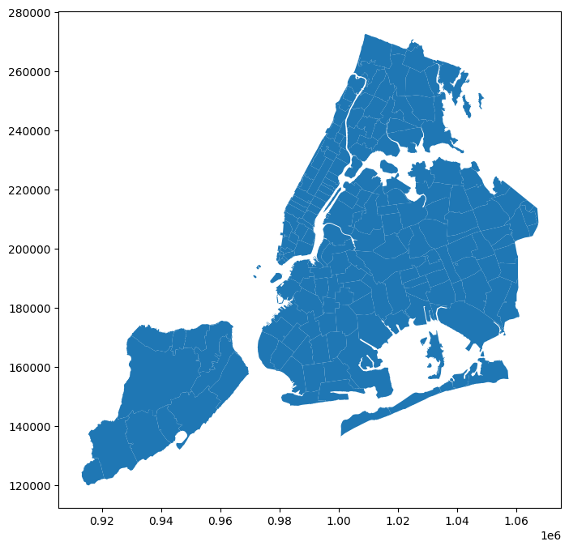

```python
zips.plot(figsize=(8,8))
```

```python
# Todo: filter out crime point beyond NYC
```

```python
# Ensure there are no missing values in the Longitude and Latitude columns
data_type1 = data_type1.dropna(subset=['Longitude', 'Latitude'])
```

```python
# Convert the crime data to a GeoDataFrame
gdf_crimes = gpd.GeoDataFrame(
    data_type1, geometry=gpd.points_from_xy(data_type1.Longitude, data_type1.Latitude), crs="EPSG:4326"
)
```

```python
# Check the CRS of the ZIP code shapefile and reproject if necessary
if zips.crs != gdf_crimes.crs:
    zips = zips.to_crs(gdf_crimes.crs)
```

```python
# Perform spatial join to keep only crimes within NYC ZIP code boundaries
gdf_nyc_crimes = gpd.sjoin(gdf_crimes, zips, predicate='within', how='inner')
```

```python
# Check the shape of the filtered data to ensure it's within the expected range
print(f"Shape of data after spatial join: {gdf_nyc_crimes.shape}")
```

```
Shape of data after spatial join: (548628, 52)
```

```python
# Drop duplicates based on the unique complaint number (CMPLNT_NUM) column
gdf_nyc_crimes = gdf_nyc_crimes.drop_duplicates(subset=['CMPLNT_NUM'])
```

```python
# Check the number of unique complaint numbers in both datasets
original_unique = data_type1['CMPLNT_NUM'].nunique()
filtered_unique = gdf_nyc_crimes['CMPLNT_NUM'].nunique()

print(f"Original unique complaints: {original_unique}")
print(f"Filtered unique complaints: {filtered_unique}")
```

```
Original unique complaints: 548419
Filtered unique complaints: 548229
```

```python
# Investigate if there are any records that are not present in the original data
extra_records = gdf_nyc_crimes[~gdf_nyc_crimes['CMPLNT_NUM'].isin(data_type1['CMPLNT_NUM'])]
print(f"Number of extra records after join: {extra_records.shape[0]}")
```

```
Number of extra records after join: 0
```

```python
import os

# Save the filtered data to CSV for further analysis
if not os.path.exists('NYC_crimes'):
    os.makedirs('NYC_crimes')

gdf_nyc_crimes.to_csv('NYC_crimes/crimes_NYC.csv')
```

```python
# YourDataframe.to_csv('NYC_crimes/crimes_NYC.csv')
```

## Section 2 -Exploratory analysis tasks

1. Visualize the time series of the total number of type 1 crimes for the whole city per day.
2. Visualize part 1 crimes grouped on a) borough level as a bar plot and b) zip code level as a heatmap normalized by population (per 100,000). Use quantiles scheme colormap.
3. Plot following bar plots: the total number of part 1 crimes by a) month, b) day of week( use weekday names for labels) and c) hour of day.
4. Plot two bar plots: Day of the week and hour of the day timelines for felony vs grand larceny (normalized per 100,000 population, comparing these two types of crime on the same bar plots)
5. Compare the %% decomposition of type 1 crimes by category of crime within different boroughs by plotting pie charts for each borough

### 1. time series plotting

```python
import matplotlib.pyplot as plt
import pandas as pd
```

```python
# Todo: group total crimes by daily numbers
```

```python
# Ensure 'CMPLNT_FR_DT' is in datetime format if it's not
gdf_nyc_crimes['CMPLNT_FR_DT'] = pd.to_datetime(gdf_nyc_crimes['CMPLNT_FR_DT'], errors='coerce')
```

```python
# Group total crimes by day
daily_crimes = gdf_nyc_crimes.groupby('CMPLNT_FR_DT').size()
```

```python
# Todo: plot as a time series
```

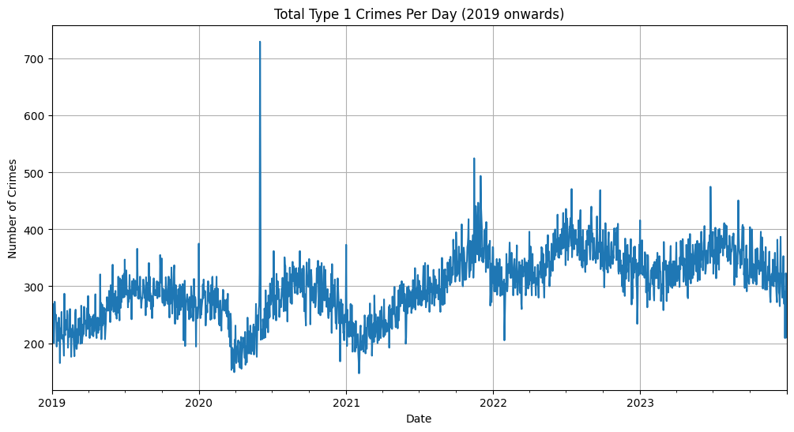

```python
# Plot the daily crimes
daily_crimes = gdf_nyc_crimes.groupby('CMPLNT_FR_DT').size()

# Plot the time series of crimes per day
plt.figure(figsize=(12, 6))
daily_crimes.plot()
plt.title("Total Type 1 Crimes Per Day (2019 onwards)")
plt.xlabel("Date")
plt.ylabel("Number of Crimes")
plt.grid(True)
plt.show()
```

### 2. plotting on borough and zip code level normalized by population

```python
# Todo: group crime numbers by borough and normalize by their population (per 100,000). Population is given in the zips shapefile
# Group by borough and count crimes
borough_crimes = gdf_nyc_crimes.groupby('BORO_NM').size()
```

```python
# Get population by borough from the 'zips' shapefile and merge with crime data
borough_population = zips.groupby('COUNTY')['POPULATION'].sum()
borough_population.index = borough_population.index.map({
    'New York': 'MANHATTAN',
    'Kings': 'BROOKLYN',
    'Bronx': 'BRONX',
    'Queens': 'QUEENS',
    'Richmond': 'STATEN ISLAND'
})
```

```python
# Normalize by population (per 100,000 residents)
borough_crimes_normalized = (borough_crimes / borough_population) * 100000
```

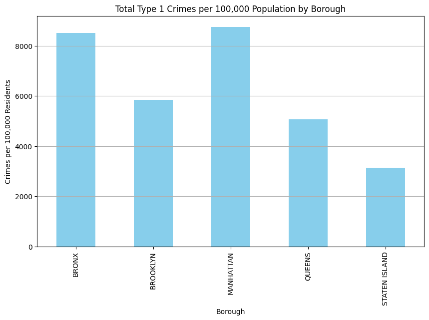

```python
# Todo: plot as a bar plot
plt.figure(figsize=(10, 6))
borough_crimes_normalized.plot(kind='bar', color='skyblue')
plt.title("Total Type 1 Crimes per 100,000 Population by Borough")
plt.ylabel("Crimes per 100,000 Residents")
plt.xlabel("Borough")
plt.grid(axis='y')
plt.show()
```

```python
# Check the available columns in zips
print(zips.columns)
```

```
Index(['ZIPCODE', 'BLDGZIP', 'PO_NAME', 'POPULATION', 'AREA', 'STATE',
       'COUNTY', 'ST_FIPS', 'CTY_FIPS', 'URL', 'SHAPE_AREA', 'SHAPE_LEN',
       'geometry'],
      dtype='object')
```

```python
pip install mapclassify
```

```python
import pandas as pd
import geopandas as gpd
import matplotlib.pyplot as plt
import mapclassify
```

```python
# Step 1: Load the zips GeoDataFrame
zips = gpd.read_file(r'C:\Users\AbdouN\Midterm\ZIPCODE.zip')
print("Loaded zips GeoDataFrame:")
print(zips.head())  # Confirm data is loaded

# Step 2: Inspect unique values
print("Unique BLDGZIP values:", zips['BLDGZIP'].unique())
print("Unique ZIPCODE values:", zips['ZIPCODE'].unique())

# Check for columns in crime_count_per_zip DataFrame
print("Columns in crime_count_per_zip DataFrame:", crime_count_per_zip.columns)

# Step 3: Merge with crime_count_per_zip DataFrame if zips is populated
if not zips.empty and not crime_count_per_zip.empty:
    # Adjust the merge operation to match the correct column names
    zips = zips.merge(crime_count_per_zip, left_on='ZIPCODE', right_on='ZIPCODE_crime', how='left')
    print("Shape after merge:", zips.shape)
else:
    print("One or both DataFrames are empty; cannot perform merge.")

# Step 4: Check for NaN values in CRIME_COUNT after merge
print("NaN values in CRIME_COUNT after merge:", zips['CRIME_COUNT'].isna().sum())

# Step 5: Calculate CRIME_RATE, ensuring no division by zero
zips['CRIME_RATE'] = zips['CRIME_COUNT'] / zips['POPULATION'].replace(0, pd.NA) * 100000

# Step 6: Check for calculated CRIME_RATE
print("CRIME_RATE statistics:")
print(zips['CRIME_RATE'].describe())
```

```
Loaded zips GeoDataFrame:
  ZIPCODE BLDGZIP   PO_NAME  POPULATION          AREA STATE  COUNTY ST_FIPS  \
0   11436       0   Jamaica     18681.0  2.269930e+07    NY  Queens      36
1   11213       0  Brooklyn     62426.0  2.963100e+07    NY   Kings      36
2   11212       0  Brooklyn     83866.0  4.197210e+07    NY   Kings      36
3   11225       0  Brooklyn     56527.0  2.369863e+07    NY   Kings      36
4   11218       0  Brooklyn     72280.0  3.686880e+07    NY   Kings      36

  CTY_FIPS                   URL  SHAPE_AREA  SHAPE_LEN  \
0      081  http://www.usps.com/         0.0        0.0
1      047  http://www.usps.com/         0.0        0.0
2      047  http://www.usps.com/         0.0        0.0
3      047  http://www.usps.com/         0.0        0.0
4      047  http://www.usps.com/         0.0        0.0

                                            geometry
0  POLYGON ((1038098.252 188138.38, 1038141.936 1...
1  POLYGON ((1001613.713 186926.44, 1002314.243 1...
2  POLYGON ((1011174.276 183696.338, 1011373.584 ...
3  POLYGON ((995908.365 183617.613, 996522.848 18...
4  POLYGON ((991997.113 176307.496, 992042.798 17...
Unique BLDGZIP values: ['0' '1']
Unique ZIPCODE values: ['11436' '11213' '11212' '11225' '11218' '11226' '11219' '11210' '11230'
 '11204' '10471' '10470' '10466' '10467' '10463' '10475' '10464' '10469'
 '10468' '10458' '10034' '10033' '10462' '10040' '10453' '10465' '10461'
 '10457' '10460' '10032' '10452' '10456' '10472' '10031' '10039' '10459'
 '10451' '10473' '10030' '10027' '10474' '10455' '10037' '10024' '10454'
 '10026' '10035' '10048' '10025' '11357' '10029' '00083' '11356' '11359'
 '11360' '11105' '10128' '10023' '11363' '10028' '11354' '11102' '11370'
 '10021' '11358' '11362' '10044' '11369' '11103' '11106' '11368' '11377'
 '11355' '11101' '11364' '10018' '10020' '11005' '10017' '10001' '10011'
 '10016' '11104' '11109' '10010' '11367' '10014' '10003' '11222' '10002'
 '11378' '10009' '10012' '10013' '10007' '11237' '11385' '10038' '11206'
 '10006' '11412' '10005' '11251' '10004' '11411' '11201' '11205' '11208'
 '11207' '11413' '11217' '11238' '11231' '11422' '11420' '11417' '11215'
 '11232' '11430' '11203' '11239' '11236' '11220' '10301' '10303' '11234'
 '10302' '11693' '11209' '10304' '10314' '11228' '11096' '10305' '11229'
 '11214' '11691' '11223' '11692' '11235' '10306' '11694' '11224' '10308'
 '11697' '10312' '10309' '10307' '10280' '11372' '11004' '11040' '11426'
 '11365' '11001' '11375' '11427' '11374' '11366' '11423' '11428' '11432'
 '11379' '11429' '11435' '11415' '11418' '11433' '11451' '11221' '11421'
 '11419' '11434' '11216' '11416' '11233' '10055' '10019' '10111' '10153'
 '10154' '10152' '10115' '10022' '10065' '10075' '10069' '10281' '10282'
 '11211' '11373' '10279' '10165' '10168' '10105' '10118' '10176' '10170'
 '10112' '10122' '10107' '10103' '10174' '10166' '10169' '10167' '10177'
 '10172' '10171' '10270' '10104' '10271' '10110' '10175' '10151' '10173'
 '10178' '10121' '10123' '10106' '10158' '10041' '10120' '10278' '10155'
 '10043' '10081' '10096' '10097' '10196' '10275' '10265' '10045' '10047'
 '10080' '10203' '10259' '10260' '10285' '10286' '11371' '11361' '10036'
 '11414' '10310' '11249' '10162' '10119']
Columns in crime_count_per_zip DataFrame: Index(['ZIPCODE_crime', 'CRIME_COUNT'], dtype='object')
Shape after merge: (263, 15)
NaN values in CRIME_COUNT after merge: 57
CRIME_RATE statistics:
count      199.00000
unique     186.00000
top       6677.52443
freq         4.00000
Name: CRIME_RATE, dtype: float64
```

```
NaN values found in CRIME_RATE, dropping NaNs for quantile calculation.
```

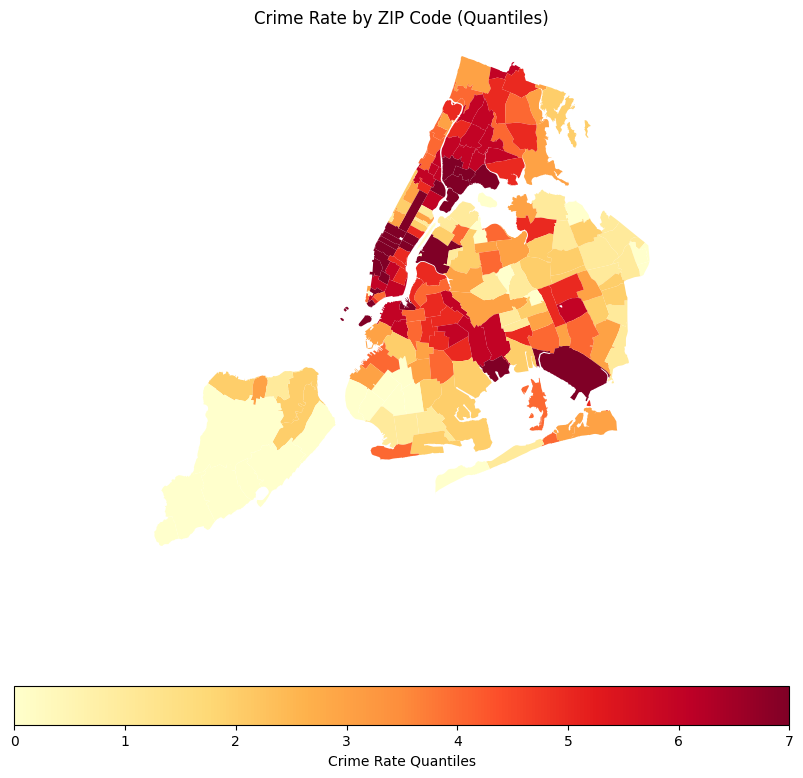

```python
# Step 7: Check for NaN values and handle them before quantile calculation
if zips['CRIME_RATE'].isna().any():
    print("NaN values found in CRIME_RATE, dropping NaNs for quantile calculation.")
    zips = zips.dropna(subset=['CRIME_RATE'])  # Drop rows where CRIME_RATE is NaN

# Step 8: Create quantile bins for the CRIME_RATE
if not zips['CRIME_RATE'].empty:
    zips['CRIME_RATE_QUANTILE'] = pd.qcut(zips['CRIME_RATE'], q=8, labels=False)

    # Step 9: Plot using quantiles
    fig, ax = plt.subplots(1, 1, figsize=(10, 10))
    zips.plot(column='CRIME_RATE_QUANTILE', cmap='YlOrRd', legend=True, ax=ax,
               legend_kwds={'label': "Crime Rate Quantiles", 'orientation': "horizontal"})

    # Customize the plot title and remove axis labels
    plt.title("Crime Rate by ZIP Code (Quantiles)")
    plt.axis('off')  # Hide axes for better visualization
    plt.show()
else:
    print("CRIME_RATE is empty; cannot perform quantile binning.")
```

### 3. bar plot of total crimes vs a) months b) day of week and c) hour of day

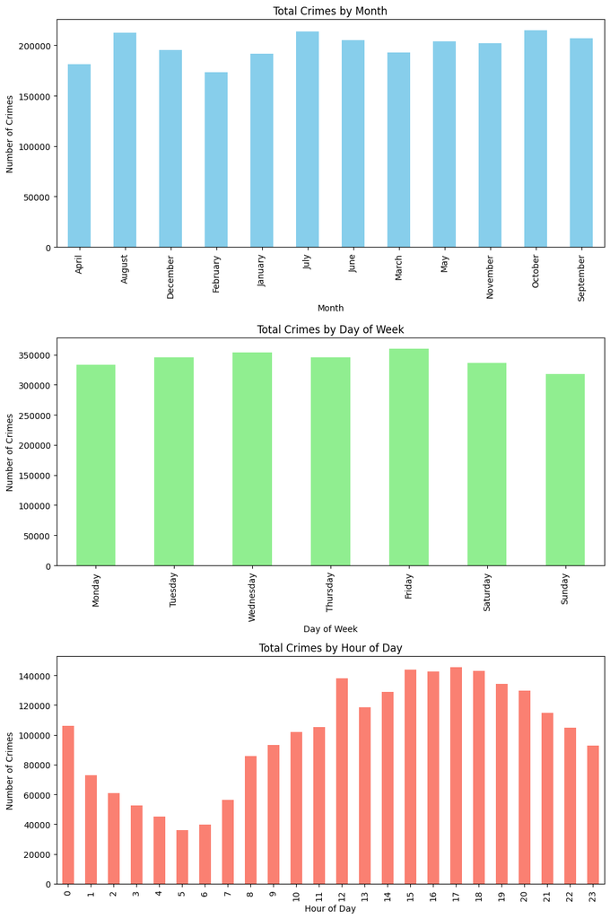

```python
import pandas as pd
import matplotlib.pyplot as plt
import seaborn as sns


# Ensure 'CMPLNT_FR_DT' is in datetime format
data['CMPLNT_FR_DT'] = pd.to_datetime(data['CMPLNT_FR_DT'], errors='coerce')

# Extract month and day of the week from the date
data['month'] = data['CMPLNT_FR_DT'].dt.month_name()  # Month names
data['day_of_week'] = data['CMPLNT_FR_DT'].dt.day_name()  # Day names

# Extract hour from the time
data['CMPLNT_FR_TM'] = pd.to_datetime(data['CMPLNT_FR_TM'], format='%H:%M:%S', errors='coerce')
data['hour'] = data['CMPLNT_FR_TM'].dt.hour  # Extract hour from the datetime object

# Group by month and count the number of crimes
crimes_by_month = data['month'].value_counts().sort_index()

# Group by day of week and count the number of crimes
crimes_by_day = data['day_of_week'].value_counts().reindex([
    'Monday', 'Tuesday', 'Wednesday', 'Thursday', 'Friday', 'Saturday', 'Sunday'
]).fillna(0)

# Group by hour and count the number of crimes
crimes_by_hour = data['hour'].value_counts().sort_index()

# Plotting
fig, axs = plt.subplots(3, 1, figsize=(10, 15))

# Bar plot for total crimes by month
crimes_by_month.plot(kind='bar', ax=axs[0], color='skyblue')
axs[0].set_title('Total Crimes by Month')
axs[0].set_xlabel('Month')
axs[0].set_ylabel('Number of Crimes')

# Bar plot for total crimes by day of the week
crimes_by_day.plot(kind='bar', ax=axs[1], color='lightgreen')
axs[1].set_title('Total Crimes by Day of Week')
axs[1].set_xlabel('Day of Week')
axs[1].set_ylabel('Number of Crimes')

# Bar plot for total crimes by hour
crimes_by_hour.plot(kind='bar', ax=axs[2], color='salmon')
axs[2].set_title('Total Crimes by Hour of Day')
axs[2].set_xlabel('Hour of Day')
axs[2].set_ylabel('Number of Crimes')

plt.tight_layout()
plt.show()
```

### 4. Bar plots: Felony assault vs grand larceny grouped by a) day of week and b) hour of day

```python
# Todo: filter data for above crime types
felony_assault = data[data['OFNS_DESC'] == 'FELONY ASSAULT']
grand_larceny = data[data['OFNS_DESC'] == 'GRAND LARCENY']
```

```python
# Todo: group the numbers and normalize by total city population (per 100,000)
# Normalize by population from the zips DataFrame
felony_assault = felony_assault.merge(zips[['ZIPCODE', 'POPULATION']], left_on='BORO_NM', right_on='ZIPCODE', how='left')
grand_larceny = grand_larceny.merge(zips[['ZIPCODE', 'POPULATION']], left_on='BORO_NM', right_on='ZIPCODE', how='left')

# Calculate normalized crime counts
felony_assault['normalized_count'] = (1 / felony_assault['POPULATION']) * 100000
grand_larceny['normalized_count'] = (1 / grand_larceny['POPULATION']) * 100000
```

[figure not shown]

```python
# Todo: plot two bar plots: one for day of week and other for hour of day
# Group by day of week
felony_assault_by_day = felony_assault['day_of_week'].value_counts().reindex([
    'Monday', 'Tuesday', 'Wednesday', 'Thursday', 'Friday', 'Saturday', 'Sunday'
]).fillna(0)

grand_larceny_by_day = grand_larceny['day_of_week'].value_counts().reindex([
    'Monday', 'Tuesday', 'Wednesday', 'Thursday', 'Friday', 'Saturday', 'Sunday'
]).fillna(0)

# Group by hour of the day
felony_assault_by_hour = felony_assault['hour'].value_counts().sort_index()
grand_larceny_by_hour = grand_larceny['hour'].value_counts().sort_index()

# Normalizing by total population for each crime type
total_population = zips['POPULATION'].sum()  # Get total population for normalization
felony_assault_normalized_by_hour = (felony_assault_by_hour / total_population) * 100000
grand_larceny_normalized_by_hour = (grand_larceny_by_hour / total_population) * 100000

# Plotting
fig, axs = plt.subplots(2, 1, figsize=(12, 12))

# Bar plot for felony assault vs grand larceny by day of week
bar_width = 0.35  # Set bar width

axs[0].bar(felony_assault_by_day.index, felony_assault_by_day, width=bar_width, label='Felony Assault', alpha=0.7, align='center')
axs[0].bar(grand_larceny_by_day.index, grand_larceny_by_day, width=bar_width, label='Grand Larceny', alpha=0.5, align='edge')
axs[0].set_title('Felony Assault vs Grand Larceny by Day of Week (normalized per 100,000)')
axs[0].set_xlabel('Day of Week')
axs[0].set_ylabel('Number of Crimes per 100,000')
axs[0].legend()

# Bar plot for felony assault vs grand larceny by hour of day
axs[1].bar(felony_assault_normalized_by_hour.index, felony_assault_normalized_by_hour, width=bar_width, label='Felony Assault', alpha=0.7, align='center')
axs[1].bar(grand_larceny_normalized_by_hour.index, grand_larceny_normalized_by_hour, width=bar_width, label='Grand Larceny', alpha=0.5, align='edge')
axs[1].set_title('Felony Assault vs Grand Larceny by Hour of Day (normalized per 100,000)')
axs[1].set_xlabel('Hour of Day')
axs[1].set_ylabel('Number of Crimes per 100,000')
axs[1].legend()

plt.tight_layout()
plt.show()
```

## Section 3 - Hypothesis testing tasks

1. Plot the distribution (density plot) of daily number of total type 1 crimes for 2019. Test the hypothesis if the distribution follows normal distribution.
2. Plot the distributions (density plots) of daily number of total type 1 crimes for weekdays and weekends (normalized by population) and perform a) the t-test for the hypothesis that the average daily crime over weekdays and weekends is the same, b) the KS-test for the hypothesis that the weekday and weekend daily crime numbers follow the same distribution. Can you reject either hypothesis at the 10% significance level?

```python
#introduce a custom function performing distribution analysis
def distribution_analysis(x, log_scale = False, fit_distribution = 'None', bins = 50, vis_means = True, vis_curve = True, print_outputs = True):
    #x - array of observations
    #log_scale - analyze distribution of log(x) if True
    #fit_distribution - fit the distribution ('normal', 'gev' or 'pareto') or do nothing if 'None'
    #bins - how many bins to use for binning the data
    #vis_means - show mean and std lines if True
    #vis_curve - show interpolated distribution curve over the histogram bars if True
    #print_outputs - print mean, std and percentiles

    if log_scale:
        x1 = np.log10(x) #convert data to decimal logarithms
        xlabel = 'log(values)' #reflect in x labels
    else:
        x1 = x #leave original scale
        xlabel = 'values'
    mu = x1.mean() #compute the mean
    if log_scale: #if logscale, output all three - log mean, its original scale and original scale mean
        print('Log mean = {:.2f}({:.2f}), mean = {:.2f}'.format(mu,10**mu,x.mean()))
    else:
        print('Mean = {:.2f}'.format(mu)) #otherwise print mean
    sigma = x1.std() #compute and output standard deviation
    print('Standard deviation = {:.2f}'.format(sigma))
    for p in [1,5,25,50,75,95,99]: #output percentile values
        print('{:d} percentile = {:.2f}'.format(p,np.percentile(x,p)))

    #visualize histogram and the interpolated line (if vis_curve=True) using seaborn
    sns.distplot(x1, hist=True, kde=vis_curve,
        bins=bins,color = 'darkblue',
        hist_kws={'edgecolor':'black'},
        kde_kws={'linewidth': 4})

    #show vertical lines for mean and std if vis_means = True
    if vis_means:
        plt.axvline(mu, color='r', ls='--', lw=2.0)
        plt.axvline(mu-sigma, color='g', ls='--', lw=2.0)
        plt.axvline(mu+sigma, color='g', ls='--', lw=2.0)

    ylim = plt.gca().get_ylim() #keep the y-range of original distribution density values
    #(to make sure the fitted distribution would not affect it)

    h = np.arange(mu - 3 * sigma, mu + 3 * sigma, sigma / 100) #3-sigma visualization range for the fitted distribution
    pars = None #fitted distribution parameters

    #fit and visualize the theoretic distribution
    if fit_distribution == 'normal':
        pars = norm.fit(x1)
        plt.plot(h,norm.pdf(h,*pars),'r')
    elif fit_distribution == 'gev':
        pars = gev.fit(x1)
        plt.plot(h,gev.pdf(h,*pars),'r')
    elif fit_distribution == 'pareto':
        pars = pareto.fit(x1)
        plt.plot(h,pareto.pdf(h,*pars),'r')

    plt.xlabel(xlabel) #add x label
    plt.ylim(ylim) #restore the y-range of original distribution density values
    plt.show()
    return pars
```

### 1. plotting distributions and normality test

```python
# Todo: group type 1 crime numbers per day for 2019
# Filter for the year 2019
data_2019 = data[data['CMPLNT_FR_DT'].dt.year == 2019]

# Group by date and count total crimes per day
daily_crimes = data_2019.groupby('CMPLNT_FR_DT')['CMPLNT_NUM'].count().reset_index()
daily_crimes.columns = ['date', 'total_crimes']  # Rename columns for clarity
```

[figure not shown]

```python
# Todo: plot the distribution (density plot)
# Plotting the distribution of daily total type 1 crimes
plt.figure(figsize=(10, 6))
sns.kdeplot(daily_crimes['total_crimes'], fill=True, color='blue')
plt.title('Density Plot of Daily Total Type 1 Crimes for 2019')
plt.xlabel('Number of Crimes')
plt.ylabel('Density')
plt.axvline(daily_crimes['total_crimes'].mean(), color='red', linestyle='--', label='Mean')
plt.legend()
plt.show()
```

```python
# Todo: normality test
# Normality Test
from scipy.stats import shapiro

# Perform Shapiro-Wilk test
stat, p_value = shapiro(daily_crimes['total_crimes'])
print('Shapiro-Wilk Test Statistic:', stat)
print('p-value:', p_value)

# Interpret the p-value
alpha = 0.05
if p_value > alpha:
    print('Fail to reject the null hypothesis (data follows normal distribution)')
else:
    print('Reject the null hypothesis (data does not follow normal distribution)')
```

```
Shapiro-Wilk Test Statistic: 0.9550330081833396
p-value: 4.027592712165521e-09
Reject the null hypothesis (data does not follow normal distribution)
```

### weekdays vs weekend distribution

```python
# Todo: create dataframes for weekdays and weekends
daily_crimes['day_of_week'] = daily_crimes['date'].dt.day_name()
```

```python
# Todo: group daily numbers for weekdays and weekends
weekdays = daily_crimes[daily_crimes['day_of_week'].isin(['Monday', 'Tuesday', 'Wednesday', 'Thursday', 'Friday'])]
weekends = daily_crimes[daily_crimes['day_of_week'].isin(['Saturday', 'Sunday'])]
```

[figure not shown]

```python
# Todo: plot distribution (density plot)
plt.figure(figsize=(10, 6))
sns.kdeplot(weekdays['total_crimes'], fill=True, color='blue', label='Weekdays')
sns.kdeplot(weekends['total_crimes'], fill=True, color='orange', label='Weekends')
plt.title('Density Plot of Daily Type 1 Crimes: Weekdays vs Weekends')
plt.xlabel('Number of Crimes')
plt.ylabel('Density')
plt.axvline(weekdays['total_crimes'].mean(), color='red', linestyle='--', label='Weekdays Mean')
plt.axvline(weekends['total_crimes'].mean(), color='purple', linestyle='--', label='Weekends Mean')
plt.legend()
plt.show()
```

```python
import pandas as pd
import numpy as np
import seaborn as sns
import matplotlib.pyplot as plt
from scipy.stats import ttest_ind, ks_2samp, shapiro
```

```python
# Todo: t-test
t_stat, p_ttest = ttest_ind(weekdays['total_crimes'], weekends['total_crimes'])
print('T-Test Statistic:', t_stat)
print('T-Test p-value:', p_ttest)
```

```
T-Test Statistic: 4.178636050874144
T-Test p-value: 3.67810379163111e-05
```

```python
# Todo: k-s test
ks_stat, p_ks = ks_2samp(weekdays['total_crimes'], weekends['total_crimes'])
print('K-S Statistic:', ks_stat)
print('K-S p-value:', p_ks)
```

```
K-S Statistic: 0.285956380783967
K-S p-value: 7.260693992280101e-06
```

```python
alpha = 0.05  # Set your significance level
if p_ttest < alpha:
    print('Reject the null hypothesis for the T-Test (average daily crime differs)')
else:
    print('Fail to reject the null hypothesis for the T-Test (average daily crime does not differ)')

if p_ks < alpha:
    print('Reject the null hypothesis for the K-S Test (distributions differ)')
else:
    print('Fail to reject the null hypothesis for the K-S Test (distributions do not differ)')
```

```
Reject the null hypothesis for the T-Test (average daily crime differs)
Reject the null hypothesis for the K-S Test (distributions differ)
```